# EDA

Aga, Karla, Nisse, Ole

2023-11-30

# Bike sharing

## Load data

Data set is acquired from [machine-learning repo](https://archive.ics.uci.edu/dataset/275/bike+sharing+dataset).

Import the required dependencies.

```r
library(tidyverse)
library(fastDummies)
library(kableExtra)
```

Proceed to read the data.

```r
source_data <- read.csv("../data/hour.csv", header = TRUE, sep = ",") %>%
    as_tibble()
```

Sub-select variables for linear model:

```r
data <- select(source_data, dteday, hr, holiday, weathersit, temp, atemp, hum, windspeed, cnt)
```

## Preprocessing

### Missing data

```r
anyNA(data)
```

```
## [1] FALSE
```

That said, missing values can still be represented as numeric values (e.g.  
`0`, `999`, `inf`). Therefore we check for non-standard formatted missing values by  
looking at the distributions of the predictor values.  
One thing worth noting, the `windspeed` distribution seems to have no lower values except for `0`. This raises the question whether `0` is truly a value, or perhaps is a substitute for missing data.

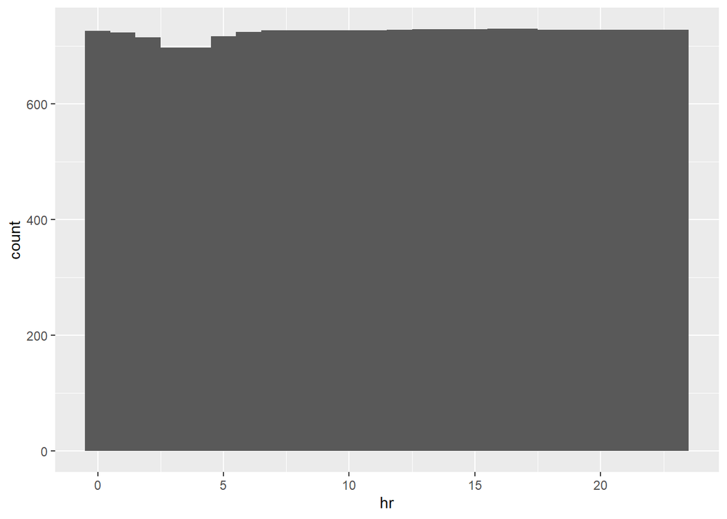

```r
# hr
ggplot(data, aes(x = hr)) +
    geom_histogram(binwidth = 1)
```

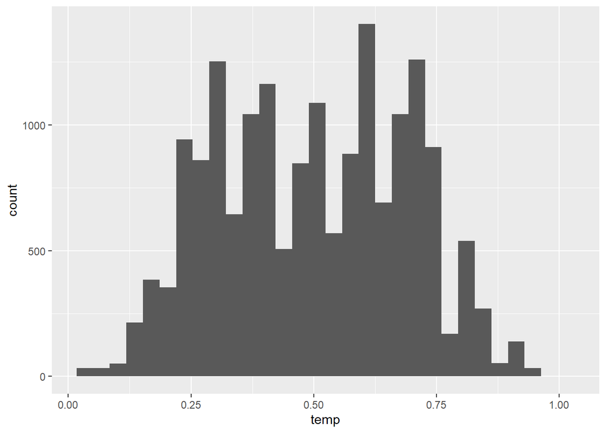

```r
# temp
ggplot(data, aes(x = temp)) +
    geom_histogram()
```

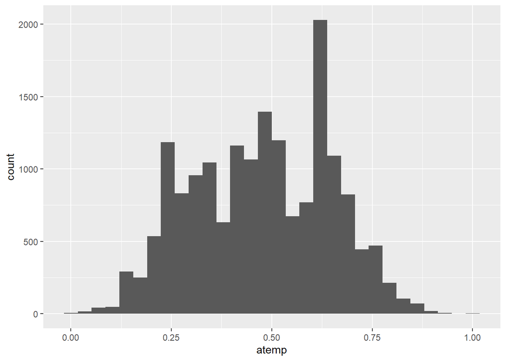

```r
# atemp
ggplot(data, aes(x = atemp)) +
    geom_histogram()
```

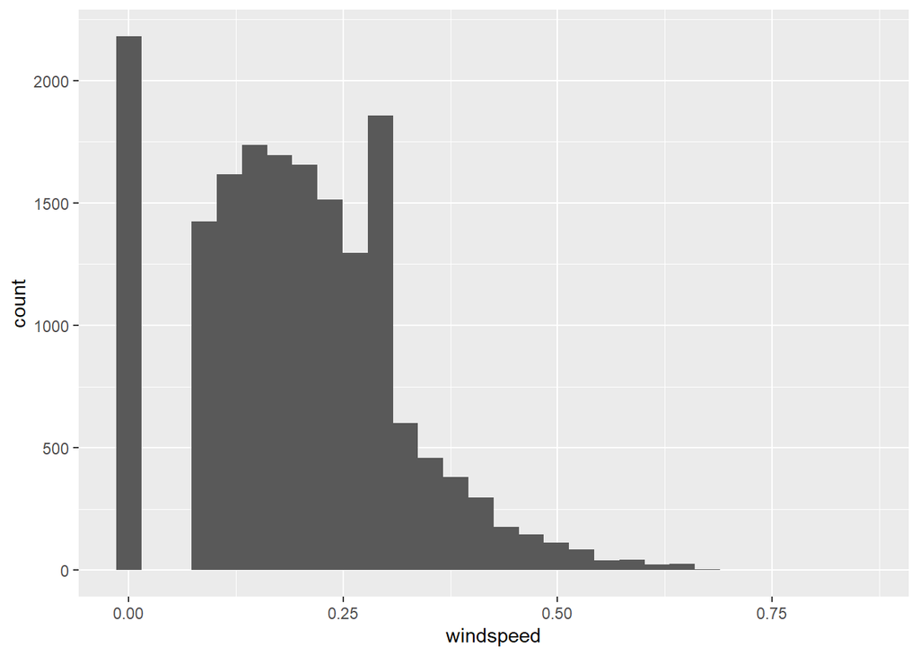

```r
# windspeed
ggplot(data, aes(x = windspeed)) +
    geom_histogram()
```

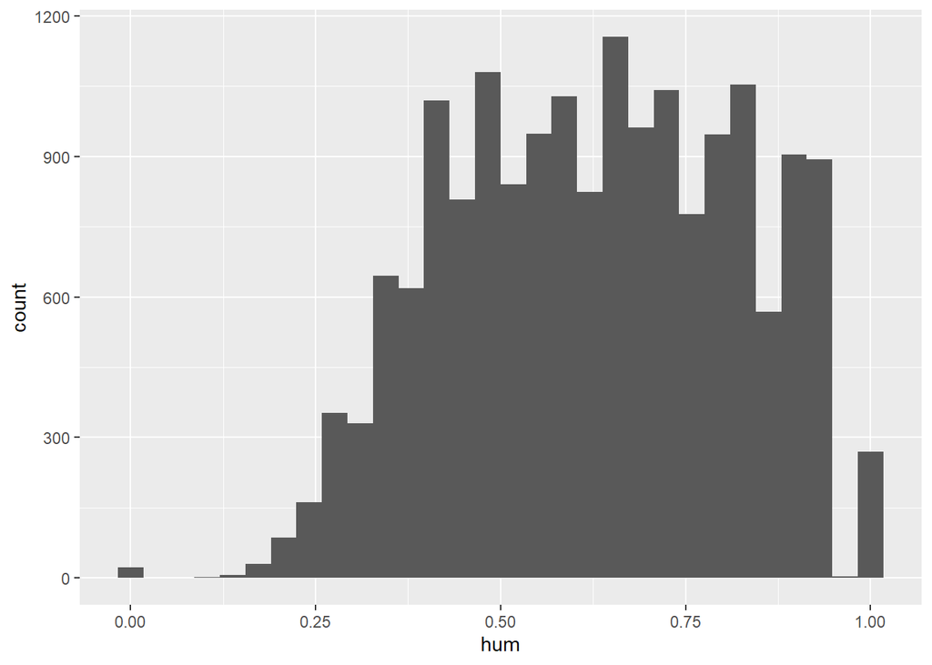

```r
# hum
ggplot(data, aes(x = hum)) +
    geom_histogram()
```

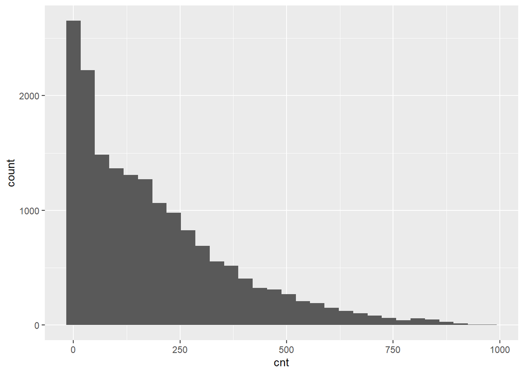

```r
# cnt
ggplot(data, aes(x = cnt)) +
    geom_histogram()
```